# Analytics en Analytics

Pablo Tempone

1 de febrero de 2017

## Introducción

Todos los años se habla de los informes de Gartner y Forrester, las empresas lo utilizan como campaña de marketing. Pero todos nos preguntamos cuando lo vemos, como es que está en esa posición, ellos lo explican para que se entienda su metodología.

Pero para buscar otra visión vamos a ver los datos que los especialistas en esos informes mencionan y como se pueden ubicar de otra manera las distintas herramientas de BI, con el foco en las que son para explotación de la información.

Lo que se busca es desmitificar cuando se habla de que hacen analytics herramientas que tienen como fuerte las visualizaciones en realidad y como esas herramientas se encuentran cercanas entre si.

## Forrester

Primero se ven los datos puros recopilados:

| Variable | Actuate | Birst | GoodData | Information.Builders | Tibco.Jaspersoft | Microsoft | MicroStrategy | Panorama.Software | Pentaho | Qlik | SAP | SAS | Tableau.Software | Tibco.Software |
| --- | --- | --- | --- | --- | --- | --- | --- | --- | --- | --- | --- | --- | --- | --- |
| IT-enabled end user self- service | 4 | 5 | 3 | 5 | 2 | 5 | 5 | 4 | 3 | 5 | 5 | 5 | 5 | 5 |
| End user self-service — provisioning | 5 | 4 | 2 | 4 | 2 | 5 | 4 | 3 | 4 | 5 | 4 | 5 | 3 | 5 |
| End user self-service — data integration | 3 | 4 | 3 | 5 | 4 | 4 | 4 | 3 | 4 | 5 | 5 | 4 | 3 | 4 |
| End user self-service — user interface | 2 | 2 | 2 | 4 | 2 | 5 | 3 | 3 | 2 | 4 | 4 | 3 | 3 | 5 |
| BI automation | 2 | 2 | 2 | 2 | 2 | 3 | 2 | 2 | 2 | 2 | 4 | 3 | 2 | 4 |
| Advanced data visualization content | 3 | 4 | 3 | 3 | 3 | 3 | 3 | 4 | 3 | 3 | 4 | 3 | 4 | 3 |
| Advanced data visualization functionality | 5 | 4 | 3 | 4 | 3 | 5 | 5 | 3 | 3 | 4 | 4 | 5 | 5 | 4 |
| Agile BI — clicks to answer | 1 | 2 | 3 | 3 | 2 | 3 | 3 | 3 | 2 | 3 | 5 | 3 | 2 | 5 |
| Agile BI — client feedback | 4 | 5 | 3 | 4 | 4 | 4 | 5 | 5 | 4 | 5 | 4 | 4 | 5 | 4 |
| End user self-service — client feedback | 4 | 4 | 3 | 5 | 5 | 4 | 5 | 5 | 5 | 5 | 4 | 4 | 5 | 5 |
| ADV — client feedback | 4 | 5 | 4 | 5 | 4 | 4 | 5 | 5 | 4 | 5 | 4 | 4 | 5 | 5 |
| Commitment — R&D spending/size of R&D team | 3 | 1 | 2 | 3 | 2 | 2 | 4 | 2 | 2 | 3 | 2 | 5 | 3 | 3 |
| Product direction | 4 | 4 | 4 | 5 | 3 | 5 | 4 | 3 | 3 | 4 | 5 | 5 | 4 | 4 |
| Corporate and product vision customer feedback | 4 | 4 | 4 | 5 | 4 | 4 | 5 | 4 | 4 | 5 | 4 | 4 | 5 | 4 |
| Company fi nancials | 2 | 1 | 1 | 3 | 1 | 5 | 3 | 1 | 1 | 3 | 5 | 5 | 2 | 5 |

Ahora se pasan esos datos una visualización más simple de ver:

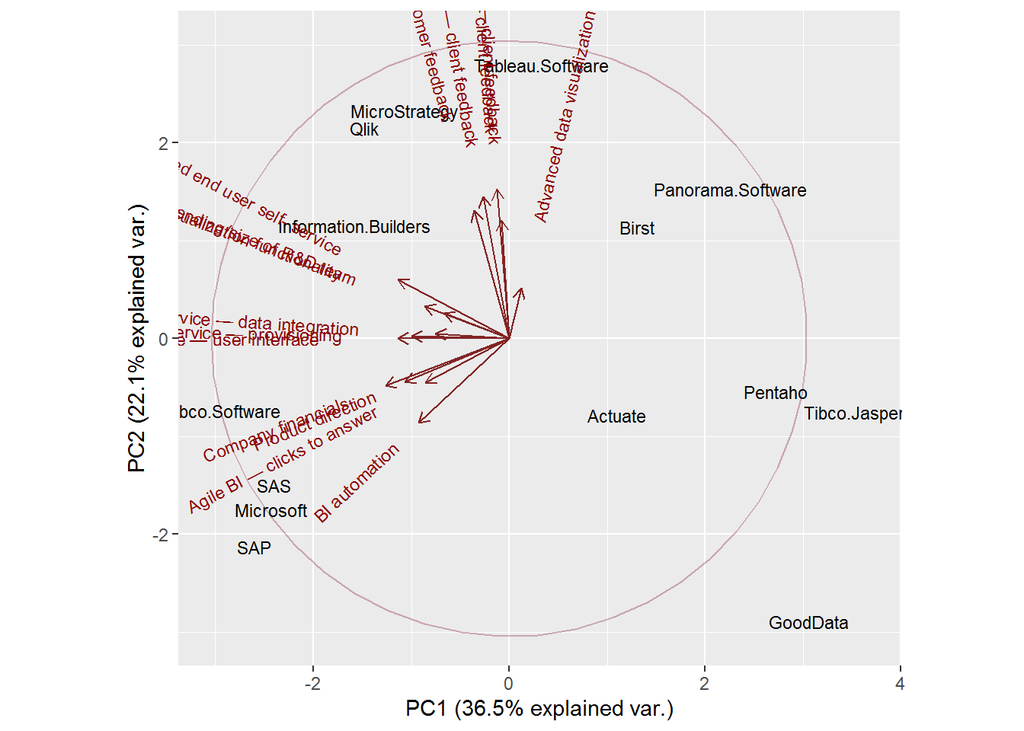

Lo que vemos cuando miramos Microstrategy, Qlikview y Tableau es que se destacan en lo siguiente:

- Visualizaciones Avanzadas
- Autoservicio del usuario final – feedback del cliente
- Visión del cliente corporativo acerca del producto
- Visualizaciones Avanzadas – feedback de clientes
- BI Ágil — feedback de clientes

## Gartner - Casos de Uso

Ahora se pasa a ver Gartner, el generador del “Cuadrante Mágico”. Primero se ven los datos de los casos de uso.

Los datos:

```r
kable(Gartner.Scores)
```

| Use.Cases | Centralized_BI_Provisioning | Decentralized.Analytics | Governed.Data.Discovery | OEM.Embedded.BI | Extranet.Deployment |
| --- | --- | --- | --- | --- | --- |
| Alteryx | 2.60 | 2.73 | 2.53 | 2.15 | 2.58 |
| BeyondCore | 2.25 | 2.28 | 2.05 | 1.95 | 2.30 |
| Birst | 3.65 | 3.43 | 3.60 | 4.00 | 4.13 |
| Board International | 2.83 | 2.80 | 2.70 | 2.58 | 2.55 |
| ClearStory Data | 3.50 | 3.43 | 3.55 | 3.73 | 3.70 |
| Datawatch | 2.60 | 2.95 | 2.90 | 2.65 | 2.28 |
| Domo | 2.73 | 2.18 | 2.40 | 2.40 | 2.75 |
| GoodData | 3.33 | 2.80 | 3.18 | 3.58 | 3.60 |
| IBM | 2.00 | 2.28 | 2.08 | 2.43 | 2.65 |
| Information Builders | 3.13 | 3.03 | 3.10 | 3.78 | 3.45 |
| Logi Analytics | 3.10 | 3.30 | 3.20 | 4.05 | 3.60 |
| Microsoft | 2.93 | 2.93 | 2.95 | 3.15 | 3.45 |
| Microstrategy | 3.63 | 3.08 | 3.35 | 3.38 | 3.70 |
| Pentaho | 3.08 | 2.90 | 2.85 | 3.60 | 3.20 |
| Platfora | 2.80 | 2.88 | 2.93 | 3.80 | 3.28 |
| Pyramid Analytics | 3.30 | 3.23 | 3.40 | 3.28 | 3.25 |
| Qlick | 2.65 | 2.98 | 2.90 | 3.28 | 2.93 |
| Salesforce | 2.53 | 2.18 | 2.28 | 2.20 | 2.75 |
| SAP | 2.88 | 2.98 | 2.90 | 2.73 | 2.63 |
| SAS | 3.70 | 3.80 | 3.60 | 2.98 | 3.20 |
| Sisense | 2.55 | 2.93 | 2.80 | 2.70 | 2.93 |
| Tableau | 2.80 | 3.05 | 2.90 | 3.03 | 3.03 |
| TIBCO software | 3.00 | 3.38 | 3.05 | 3.50 | 3.40 |
| Yellowfin | 3.05 | 2.75 | 3.00 | 3.03 | 2.73 |

Ahora se vuelve a generar un gráfico para visualizar mejor esas variables y cada una de las herramientas.

Las variables son las siguientes:

- Descentralización
- Centralización
- Gobierno de datos
- OEM/Embedded BI
- Despliegue Extranet

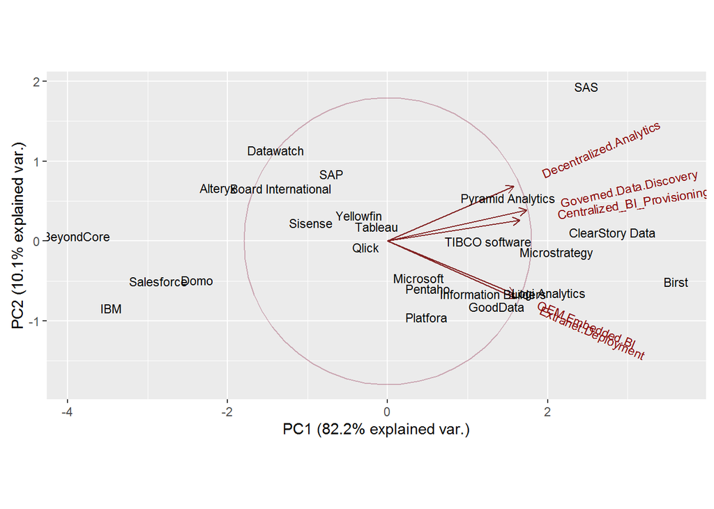